# Correlations between ADI-R Subscore A and Individual Specific DEGs

## 1. Introduction

Velmeshev, Dmitry, et al. (2019)에서 ASD 환자들의 single-cell profiles와 대조군의 profiles를 비교한 결과 L2/3, L5/6-CC을 포함한 여러 cell type에서 환자들의 ADI-R scores와 상관관계를 보였다. 또한 ADI-R scores와 가장 상관관계가 높은 differentially expressed genes (DEGs)는 transcriptional dysregulation의 정도가 높은 DEGs과는 관련이 적었다. 따라서, 유전자 발현량의 Fold change(ASD versus control) 수치보다는 환자들의 individual specific DEGs의 수와 ADI-R score의 상관관계를 분석하고자 한다.

이 Portfolio에서는 ADI-R score 중에서 reciprocal social interaction의 이상 정도를 나타내는 A score와 cell type마다 갖고 있는 individual specific DEGs의 수를 비교한다. 환자들의 ADI-R A score는 위 논문의 Data S1에서 확인할 수 있었고, Individual specific DEGs는 Data S4에서 5명 이상의 환자로부터 유의적으로 발현량 차이가 있는 유전자를 이용하였다.

## 2. Data Pre-processing

우선, excel 파일을 불러오고 데이터를 처리할 수 있는 Package를 불러온다.

```r
# Load packages
library(tidyverse)
library(readxl)
```

이제 사용할 데이터를 읽어보자.

```r
# Read excel files
S1_1 <- read_excel("aav8130_Data_S1.xlsx")
S4_4 <- read_excel("aav8130_Data_S4.xls", sheet = 4)
```

데이터가 잘 읽혔는지 확인해 본다.

```r
colnames(S1_1)
```

```
##  [1] "Patient ID"      "Diagnosis"       "Age"             "Sex"
##  [5] "PMI"             "Other diagnoses" "Medications"     "ADI-R"
##  [9] "...9"            "...10"           "...11"           "...12"
## [13] "Cause of death"
```

```r
colnames(S4_4)
```

```
## [1] "Cell type"
## [2] "Gene ID"
## [3] "Gene name"
## [4] "Direction of change (ASD/Control)"
## [5] "# of ASD patients with significant change"
## [6] "ASD patients with DE signal"
```

`S1_1`의 데이터를 살펴보면 `S1_1`의 열 이름 중에 ADI-R scores가 누락되어 1행이 존재하는 것을 알 수 있다. 따라서 1행을 삭제해 주고 열 이름을 다시 지정해주어야 한다.

```r
S1_1 <- S1_1[-1,]
colnames(S1_1)[8:12] <- c('A','Bv','Bnv','C','D')
```

대조군 집단과 일부 환자들의 `A` score가 결측치로 되어 있기 때문에 `filter` 함수를 통해 이를 제외한다. 또한 `Patient ID`는 범주형 변수로 활용하기 위해 character로, `A` score는 양적 변수로 활용하기 위해 numeric으로 class를 바꾸어 준다. 사용할 정보는 이 두 개의 정보 밖에 없으므로 `select` 함수로 간단하게 해준다.

```r
S1_1 <- S1_1 %>% filter(!(A=='NA')) %>%
  mutate('Patient ID' = as.character(`Patient ID`), A = as.numeric(A)) %>% select(`Patient ID`, A)
S1_1
```

| Patient ID | A |
| --- | --- |
| 5278 | 22 |
| 5144 | 28 |
| 5403 | 30 |
| 5419 | 24 |
| 4899 | 22 |
| 5978 | 13 |
| 6033 | 26 |
| 5864 | 18 |
| 5939 | 29 |
| 5565 | 27 |

[output cut: 2 more lines]

`S4_4`의 데이터의 경우 우리가 사용할 patient ID 정보가 `ASD patients with DE signal`에 한 문자열로 묶여 있다. 환자마다 각각의 유전자가 DEGs인지 확인하기 위해서 `str_count` 함수를 이용하여 `ASD patients with DE signal`에서 추출된 patient ID들 중에 알고 싶은 환자 ID가 포함되어 있는지 확인하면 된다. 해당 환자 ID가 포함되어 있다면 `1`이, 포함되어 있지 않다면 `0`이 결과값이 된다. A score를 갖고 있는 모든 환자에 대해서 조사하려면 `sapply` 함수를 사용한다. 이를 통해 생성된 data.frame을 `ind_DEGs`에 지정한다.

```r
ind_DEGs <- sapply(S1_1$`Patient ID`,
                     function(ID) str_count(S4_4$`ASD patients with DE signal`, ID))
head(ind_DEGs)
```

```
##      5278 5144 5403 5419 4899 5978 6033 5864 5939 5565 5294 4849
## [1,]    0    0    0    0    0    1    1    1    1    1    0    1
## [2,]    0    0    1    0    0    0    1    0    0    1    0    1
## [3,]    0    0    1    0    1    1    0    1    1    1    0    1
## [4,]    0    0    0    0    0    0    1    1    0    1    0    1
## [5,]    0    1    0    0    0    1    1    0    1    1    0    1
## [6,]    0    1    0    0    0    0    0    1    1    1    0    1
```

`cbind` 함수를 이용하여 `ind_DEGs`를 S4_4에 붙여보자.

```r
S4_4 <- cbind(S4_4, ind_DEGs)
```

이제 환자마다 cell type에 따른 indivisual specific DEGs의 수를 찾아본다. `group_by` 함수로 `Cell type`에 따라 grouping하고 각 환자에 대해서 `ind_DEGs` 행들의 합을 구한다. `summarize_at` 함수를 통해 각 환자의 DEGs 수를 한꺼번에 구할 수 있다. 이 결과를 `DEGs_num`에 지정한다.

```r
DEGs_num <- S4_4 %>% group_by(`Cell type`) %>%
  summarise_at(vars(`5278`:`4849`), sum)
DEGs_num
```

| Cell type | 5278 | 5144 | 5403 | 5419 | 4899 | 5978 | 6033 | 5864 | 5939 | 5565 | 5294 | 4849 |
| --- | --- | --- | --- | --- | --- | --- | --- | --- | --- | --- | --- | --- |
| AST-FB | 0 | 0 | 0 | 3 | 4 | 9 | 6 | 11 | 10 | 8 | 2 | 5 |
| AST-PP | 5 | 11 | 39 | 24 | 4 | 71 | 42 | 66 | 44 | 47 | 5 | 23 |
| END | 1 | 1 | 0 | 0 | 7 | 13 | 2 | 10 | 9 | 13 | 3 | 14 |
| IN-PV | 0 | 7 | 10 | 2 | 6 | 43 | 27 | 50 | 55 | 68 | 0 | 32 |
| IN-SST | 1 | 6 | 1 | 2 | 3 | 10 | 7 | 6 | 12 | 13 | 1 | 3 |
| IN-SV2C | 0 | 2 | 1 | 0 | 0 | 8 | 10 | 8 | 10 | 12 | 1 | 3 |
| IN-VIP | 12 | 20 | 17 | 14 | 1 | 53 | 27 | 31 | 59 | 53 | 9 | 18 |
| L2/3 | 58 | 96 | 135 | 80 | 104 | 170 | 196 | 142 | 201 | 198 | 34 | 132 |
| L4 | 15 | 34 | 70 | 33 | 28 | 70 | 66 | 62 | 90 | 90 | 15 | 45 |
| L5/6 | 1 | 1 | 14 | 2 | 11 | 18 | 18 | 12 | 19 | 25 | 3 | 14 |

[output cut: 7 more lines]

환자 A score와 DEGs의 수를 비교하기 위해서 우선 `gather` 함수를 이용하여 `DEGs_num`를 *long format*으로 바꿔준다. 그리고 `A` score 정보를 가진 `S1_1`를 `merge` 함수를 통해 합쳐준다. 이 data.frame을 편의를 위해 `df`라고 지정한다.

```r
# transform data.frame from wide into long format
df <- DEGs_num %>% gather(`Patient ID`, DEGs_num, -`Cell type`) %>% merge(S1_1)
```

`df`를 보면 DEGs의 수에 `0`값이 매우 많은 것을 알 수 있다 (zero-inflated data). 이는 상관관계 분석에 부적절한 영향을 주기 때문에 `0`값이 나타나는 `Cell type`은 제외한다.

```r
df <- df %>% group_by(`Cell type`) %>% filter(min(DEGs_num) > 0) %>% ungroup()
df
```

| Patient ID | Cell type | DEGs_num | A |
| --- | --- | --- | --- |
| 4849 | AST-PP | 23 | 22 |
| 4849 | IN-SST | 3 | 22 |
| 4849 | IN-VIP | 18 | 22 |
| 4849 | L2/3 | 132 | 22 |
| 4849 | L4 | 45 | 22 |
| 4849 | L5/6 | 14 | 22 |
| 4849 | L5/6-CC | 96 | 22 |
| 4849 | Neu-NRGN-II | 10 | 22 |
| 4849 | Oligodendrocytes | 7 | 22 |
| 4849 | OPC | 12 | 22 |

[output cut: 110 more lines]

## 3. Data Visualization

상관 분석을 하기 전에 우선 데이터가 어떻게 분포되어 있는지 확인해 보자.

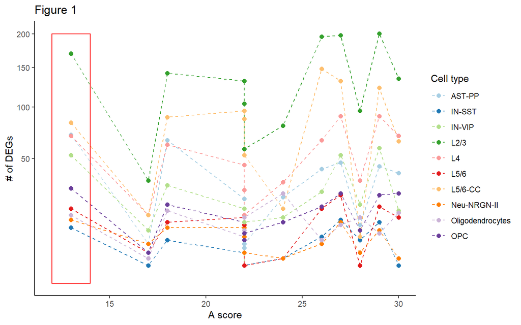

```r
library(RColorBrewer)
df %>% ggplot(aes(A, DEGs_num, color = `Cell type`)) +
  geom_line(lty = 2) + geom_point(size = 2) +
  scale_color_manual(values = brewer.pal(10, name = 'Paired')) +
  geom_rect(aes(xmin = 12, xmax = 14, ymin = 0, ymax = 200), color = 'red', fill = NA) +
  xlab("A score") + ylab("# of DEGs") + labs(color = 'Cell type') +
  scale_y_continuous(trans = 'sqrt') + theme_classic() + ggtitle("Figure 1")
```

`ggplot`를 이용하여 `Cell type`에 따른 A score와 DEGs의 수를 비교했을 때, 빨간 사각형으로 표시된 부분에 해당하는 환자의 A score가 가장 낮음에도 불구하고 DEGs의 수가 전체적으로 상당히 큰 것을 알 수 있다. `Cell type`별로 *Pearson correlation analysis*를 구해보면 다음과 같다.

```r
df %>% group_by(`Cell type`) %>%
  summarize(r = cor(A, DEGs_num, method = "pearson"), p.value = cor.test(A, DEGs_num, method = "pearson")$p.value) %>% arrange(p.value)
```

| Cell type | r | p.value |
| --- | --- | --- |
| Neu-NRGN-II | -0.4203 | 0.174 |
| L4 | 0.3254 | 0.302 |
| L2/3 | 0.2877 | 0.364 |
| AST-PP | -0.1753 | 0.586 |
| L5/6-CC | 0.1740 | 0.589 |
| OPC | 0.1618 | 0.615 |
| L5/6 | 0.1422 | 0.659 |
| IN-SST | 0.1211 | 0.708 |
| IN-VIP | 0.0526 | 0.871 |
| Oligodendrocytes | 0.0463 | 0.886 |

상관계수가 $p<.05$을 만족시키는 `Cell type`은 존재하지 않았다. 그 이유로 연구에 사용된 ASD 환자 샘플 수가 적어서 Figure 1의 빨간 부분으로 표시한 환자가 **Outlier**로서 크게 영향을 준 것으로 보인다. 이 환자를 제외하고 상관 분석을 다시 진행해 보았다.

```r
corr <- df %>% filter(A > 15) %>% group_by(`Cell type`) %>%
  summarize(r = cor(A, DEGs_num, method = "pearson"), p.value = cor.test(A, DEGs_num, method = "pearson")$p.value) %>% arrange(p.value)
corr
```

| Cell type | r | p.value |
| --- | --- | --- |
| OPC | 0.617 | 0.0432 |
| L4 | 0.595 | 0.0533 |
| L2/3 | 0.559 | 0.0736 |
| IN-VIP | 0.458 | 0.1568 |
| IN-SST | 0.437 | 0.1792 |
| L5/6 | 0.389 | 0.2365 |
| L5/6-CC | 0.256 | 0.4480 |
| AST-PP | 0.222 | 0.5121 |
| Oligodendrocytes | 0.173 | 0.6107 |
| Neu-NRGN-II | -0.168 | 0.6211 |

분석 결과 $p<.05$을 만족하는 `Cell type`은 `OPC`이고 $p<0.1$을 만족하는 `Cell type`은 `OPC`, `L4`, `L2/3`이었다. 상관관계 분석 결과와 $p<0.1$를 만족하는 `Cell type`의 `A` score와 `DEGs_num`의 분포를 `ggplot`을 이용해 나타었다.

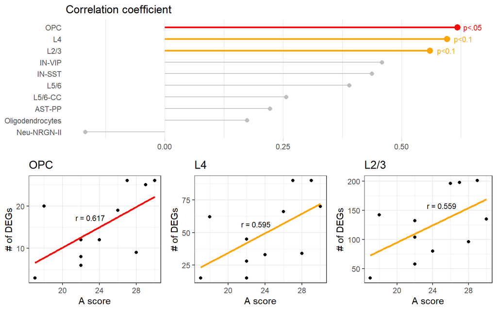

```r
library(cowplot)
p1 <- df %>% filter(A > 15 & `Cell type` == 'OPC') %>%
  ggplot(aes(A, DEGs_num)) + geom_point() +
  geom_smooth(method = 'lm', se = F, col = "red") + ggtitle('OPC') +
  geom_text(data = data.frame(x = 23, y = 17.2, text = "r = 0.617"), aes(x, y, label = text), size = 3) +
  xlab("A score") + ylab("# of DEGs") + theme_bw()
p2 <- df %>% filter(A > 15 & `Cell type` == 'L4') %>%
  ggplot(aes(A, DEGs_num)) + geom_point() +
  geom_smooth(method = 'lm', se = F, col = "orange") + ggtitle('L4') +
  geom_text(data = data.frame(x = 23, y = 56.4, text = "r = 0.595"), aes(x, y, label = text), size = 3) +
  xlab("A score") + ylab("# of DEGs") + theme_bw()
p3 <- df %>% filter(A > 15 & `Cell type` == 'L2/3') %>%
  ggplot(aes(A, DEGs_num)) + geom_point() +
  geom_smooth(method = 'lm', se = F, col = "orange") + ggtitle('L2/3') +
  geom_text(data = data.frame(x = 25, y = 158, text = "r = 0.559"), aes(x, y, label = text), size = 3) +
  xlab("A score") + ylab("# of DEGs") + theme_bw()
p4 <- corr %>% mutate(`Cell type` = reorder(`Cell type`, r)) %>%
  ggplot() +
  geom_point(aes(r, `Cell type`),
                        col = case_when(corr$`Cell type` %in% c("OPC") ~ "red",
                                        corr$`Cell type` %in% c("L4", "L2/3") ~ "orange",
                                        TRUE ~ "grey"),
                        size = ifelse(corr$`Cell type` %in% c("OPC","L4", "L2/3"), 3, 2)) +
  geom_segment(aes(0, `Cell type`, xend = r, yend = `Cell type`),
               col = case_when(corr$`Cell type` %in% c("OPC") ~ "red",
                               corr$`Cell type` %in% c("L4", "L2/3") ~ "orange",
                               TRUE ~ "grey"),
               size = ifelse(corr$`Cell type` %in% c("OPC","L4", "L2/3"), 1, 0.5)) +
  theme_light() +
  theme(
    panel.grid.major.y = element_blank(),
    panel.border = element_blank(),
    axis.ticks.y = element_blank()
  ) +
  labs(title = "Correlation coefficient", x = NULL, y = NULL) +
  annotate("text", 0.65, "OPC", label = "p<.05", col = "red", size = 3) +
  annotate("text", 0.63, "L4", label = "p<0.1", col = "orange", size = 3) +
  annotate("text", 0.595, "L2/3", label = "p<0.1", col = "orange", size = 3)
plot_grid(p4, plot_grid(p1, p2, p3, nrow = 1), nrow = 2)
```